# Wrapper function `parlMICE`

Rianne Schouten & Gerko Vink

faster, paralleler, micer

For big datasets or high number of imputations, performing multiple imputation with function `mice` from package `mice` (Van Buuren & Groothuis-Oudshoorn, 2011) might take a long time. As a solution, wrapper function `parlMICE` was created to enable the imputation procedure to be run in parallel. This is done by dividing the imputations over multiple cores (or CPUs), thus potentially speeding up the process.

This vignette demonstrates two applications of the `parlMICE` function. The first application shows the tradeoff between time and increasing number of imputations ($m$) for a small; the second application does the same, but for a relatively large dataset. We also discuss `parlMICE`’s arguments.

The function `parlMICE` depends on packages `parallel` and `mice`. For more information about running functions in parallel, see e.g. [the `parallel` manual](https://stat.ethz.ch/R-manual/R-devel/library/parallel/doc/parallel.pdf) or the entry [*How-to-go parallel in R*](http://gforge.se/2015/02/how-to-go-parallel-in-r-basics-tips/) on Max Gordon’s blog. Function `parlMICE` found its inspiration from Max’s useful suggestions on parallelization of `mice`’s chains on [`stackoverflow`](http://stackoverflow.com/questions/24040280/parallel-computation-of-multiple-imputation-by-using-mice-r-package).

### Time gain with small datasets

We demonstrate the potential gain in computing efficiency on simulated data. To this end we sample 1,000 cases from a multivariate normal distribution with mean vector

$$\mu = \left[\begin{array}
{r}
0 \\
0 \\
0 \\
0
\end{array}\right]$$

and covariance matrix

$$\Sigma = \left[\begin{array}
{rrrr}
1&0.5&0.5&0.5 \\
0.5&1&0.5&0.5 \\
0.5&0.5&1&0.5 \\
0.5&0.5&0.5&1
\end{array}\right].$$

A MCAR missingness mechanism is imposed on the data where 80 percent of the cases (i.e. rows) has missingness on one variable. All variables have missing values. The missingness is randomly generated with the following arguments from function [`mice:::ampute`](https://github.com/RianneSchouten/Amputation_with_Ampute/tree/master/Vignette):

```r
ampute(data, prop = 0.8)

# EDIT:
# At the time of running these simulations, the defaults in ampute
# resulted in MCAR missingness. The new defaults of ampute
# generate MARRIGHT missingness.
```

We compare the default ‘sequential’ function `mice` with function `parlMICE`. In both functions we use the defaults arguments for the `mice` algorithm, although these could very easily be changed if desired by the user. To demonstrate the increased efficiency when putting more than one computing core to work, we repeat the procedure with `parlMICE` for 1, 2 and 3 cores. Figure 1 shows a graphical representation of the results.

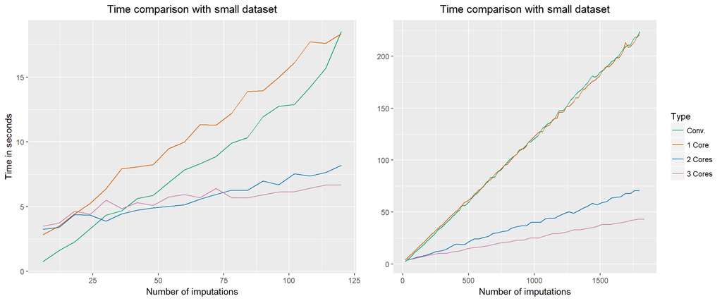

*Figure 1. Processing time for small datasets. Multiple imputations are performed with `mice` (conventional) and wrapper function `parlMICE` (1, 2 and 3 cores respectively). The dataset has 1000 cases and 4 variables with a correlation of 0.5. 80 percent of the cases has one missing value based on MCAR missingness.*

The right plot in Figure 1 shows the processing time for very high number of imputations. After the intersection, the lines follow the same trend: 3 cores execute the same amount of work faster than 2 cores, which executes faster than a single core. Naturally, using `parlMICE` with 1 core is similar to function `mice`, as the figure shows with the green and orange lines.

### Time gain with large datasets

We replicated the above detailed simulation setup with a larger dataset of 10,000 cases and 8 variables. The mean and covariance structure follow the sampling scheme of the smaller data set. We show the results of this simulation in Figure 2.

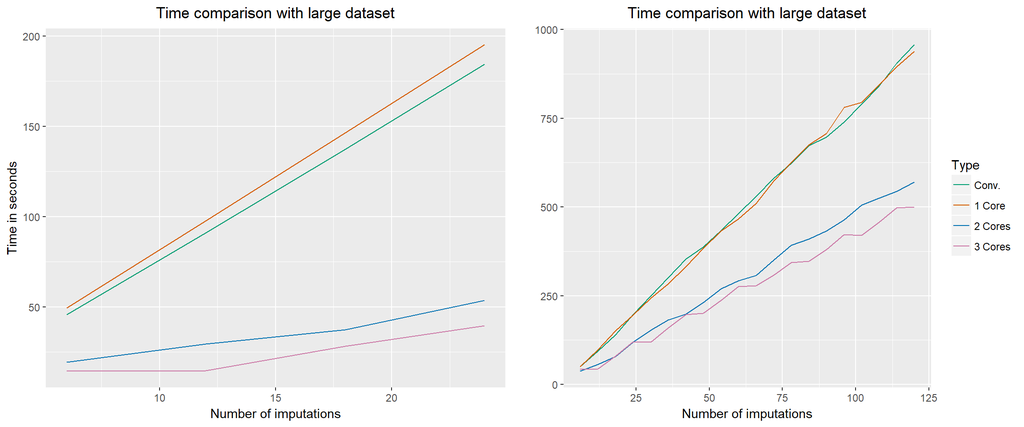

*Figure 2. Processing time for large datasets. Multiple imputations are performed with `mice` (conventional) and wrapper function `parlMICE` (1, 2 and 3 cores respectively). The dataset has 10000 cases and 8 variables with a correlation of 0.5. 80 percent of the cases has one missing value based on MCAR missingness.*

There is not a large difference between using 2 and 3 cores with wrapper function `parlMICE`. For all number of imputations, the procedure runs faster with 3 cores, even though the imputations have to be divided over the cores. It might therefore be desirable to use always as many cores as possible, while leaving 1 core out to govern any overhead computing. For example, on a hexacore machine, use only 5 cores to run the `mice` algorithm in parallel with `parlMICE`.

### Default settings

We will now discuss the arguments of function `parlMICE`. Easy imputation of an incomplete dataset (say, `nhanes`) can be performed with `parlMICE` in the following way.

```r
imp <- parlMICE(nhanes)
class(imp)
```

```
## [1] "mids"
```

The function returns a `mids` object as created by `mice`. In fact, `parlMICE` makes use of function `ibind` to combine the `mids` objects returned by the different cores. Therefore, the `call` of the `mids` object has slightly changed.

```r
imp$call
```

```
## [[1]]
## mice(data = data, m = n.imp.core, printFlag = FALSE, seed = mice.seed)
##
## [[2]]
## ibind(x = imp, y = imps[[i]])
##
## [[3]]
## ibind(x = imp, y = imps[[i]])
##
## [[4]]
## ibind(x = imp, y = imps[[i]])
##
## [[5]]
## ibind(x = imp, y = imps[[i]])
##
## [[6]]
## ibind(x = imp, y = imps[[i]])
##
## [[7]]
## ibind(x = imp, y = imps[[i]])
##
## [[8]]
## ibind(x = imp, y = imps[[i]])
##
## [[9]]
## ibind(x = imp, y = imps[[i]])
##
## [[10]]
## ibind(x = imp, y = imps[[i]])
##
## [[11]]
## ibind(x = imp, y = imps[[i]])
```

All other parts of the `mids` object are standard.

### Using `mice` arguments

Function `parlMICE` is able to deal with the conventional `mice` arguments. In order to change the imputation method from its default (predictive mean matching) to, for example, Bayesian linear regression, the `method` argument can be adjusted. For other possibilities with `mice`, we refer to the `mice` [manual](https://cran.r-project.org/web/packages/mice/mice.pdf).

```r
imp <- parlMICE(nhanes, method = "norm")
imp$method
```

```
##    age    bmi    hyp    chl
##     "" "norm" "norm" "norm"
```

In `mice`, the number of imputations is specified with argument `m`. In `parlMICE`, it is possible to use this argument as well, but we advise to rather use the arguments `n.core` and `n.imp.core`. The next section discusses these arguments.

### Arguments `n.core`, `n.imp.core`

With `n.core`, the number of cores (or CPUs) is given. `n.imp.core` defines the number of imputations per core. Subsequently, the total number of imputations equals `n.core` * `n.imp.core`.

As a default, `n.core` is specified as the number of available, logical cores minus 1. The default number of imputations per core has been set to 2. The rational behind this is to on average perform a number of imputations that is close to the default setting in `mice`, which is $m = 5$. On computing machines with 4 available, logical cores, the default number of imputations is $m = (4 - 1) * 2 = 6$.

The computer with which this vignette is run, has

```r
detectCores()
```

```
## [1] 12
```

available, logical cores. Consequently, the default `parlMICE` setting will result to 22 imputations. We can check this by evaluating the $m$ that is shown in the `mids` object.

```r
imp$m
```

```
## [1] 22
```

### Argument `seed`

In simulation studies, it is often desired to set a seed to make the results reproducible. In contrast to `mice`, the seed value for `parlMICE` cannot be defined outside the function. This has to do with the different cores running at the same time (for more information we gladly refer to the [`parallel` manual](https://stat.ethz.ch/R-manual/R-devel/library/parallel/doc/parallel.pdf)).

In `parlMICE` a seed value can be specified by making use of the argument `seed`:

```r
imp <- parlMICE(nhanes, seed = 123)
```

### Systems other than Windows

Function `parlMICE` calls for function `parLapply` from the `parallel` [package](https://stat.ethz.ch/R-manual/R-devel/library/parallel/doc/parallel.pdf). Although other options are available, we have chosen for `parLapply` because it allows for the use of multiple cores on all computers, including a Windows computer. For the cluster, we rely on the default option in the function `makeCluster` which is `"PSOCK"`.

On systems other than Windows, cluster type `"FORK"` might be faster (see document [*How-to-go parallel in R*](http://gforge.se/2015/02/how-to-go-parallel-in-r-basics-tips/) by Max Gordon). Therefore, we advise to change the type to `"FORK"` if your computer does not run on Windows.

```r
imp <- parlMICE(nhanes, type = "FORK")
```

### References

Gordon, M. (2015). How-to go parallel in R – basics + tips. Available at http://gforge.se/2015/02/how-to-go-parallel-in-r-basics-tips/

Schouten, R.M., Lugtig, P.J. and Vink, G. (last update: 2020). Generate missing values with `ampute`. Available at https://rianneschouten.github.io/mice_ampute/vignette/ampute.html

Manual base-package `Parallel`, available at https://stat.ethz.ch/R-manual/R-devel/library/parallel/doc/parallel.pdf

Manual package `MICE`, available at https://cran.r-project.org/web/packages/mice/mice.pdf

Van Buuren, S. and Groothuis-Oudshoorn, K. (2011). mice: Multivariate imputation by chained equations in R. , 45 (3).

**End of Vignette**